# Clase 01

[figure not shown]

```
Instalación, ayuda, búsquedas:
R, CRAN, R-seek, RStudio, install.packages, library
Variables y tipos, importar datos:
vectores, matrices, factores, list, asignación
dataframe, tibles
```

Una versión actualizada de este material en : [clase01](https://mar71n.github.io/rconr/apuntes2026/clase01.html)

## Instalar:

### Página principal de R:

- https://www.r-project.org/
- Descargas o CRAN lleva a : https://cran.r-project.org/mirrors.html
- Donde vemos una lista de “mirrors”.
- De Argentina : El de la [Facultad de Ciencias Astronómicas y Geofísicas - UNLP](https://www.fcaglp.unlp.edu.ar/)

http://mirror.fcaglp.unlp.edu.ar/CRAN/

- O uno general https://cloud.r-project.org/ que de alguna manera elije entre los disponibles.

Descargamos el instalador para el SO y arquitectura correspondiente.

En caso de tener una versión anterior instalada, lo mejor es desinstalarla. Ver: Upgrade en CRAN

En redes que usan un proxy para conectarse a internet: configurar proxy

### Rtools :

Para algunas instalaciones de paquetes en Windows

https://cran.r-project.org/bin/windows/Rtools/

### Rstudio :

- [posit.co](https://posit.co/products/open-source/rstudio/)
- [posit.co/downloads](https://posit.co/downloads/)

##### RStudio se conviertio en **Posit** en Octubre de 2022. [**posit.co**](https://posit.co/)

##### Posit Cloud. Rstudio en el navegador. Sín instalaciones.

- posit.co/products/enterprise/cloud

[figure not shown]

[figure not shown]

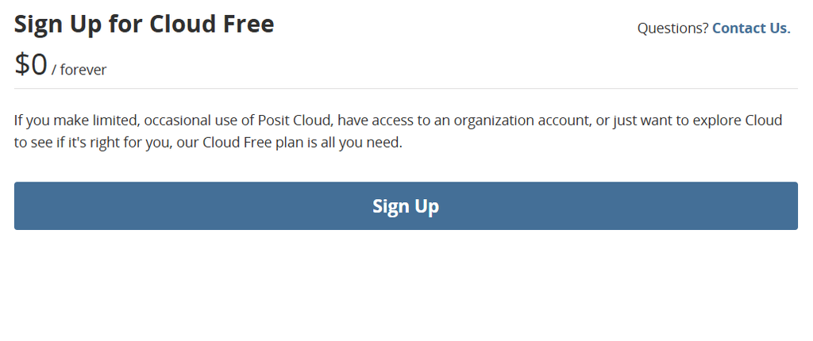

[figure not shown]

### Búsquedas y ayuda :

- https://rseek.org/
- https://www.rdocumentation.org/
- https://community.rstudio.com/
- [versión en español de Stack Overflow tag [r]](https://es.stackoverflow.com/questions/tagged/r)

### Paquetes:

#### Librería estándar :

##### Estos paquetes se instalan junto con R. Por lo que no hace falta instalarlos con *install.packages()*

##### [*Paquetes de la librería estándar*](https://stat.ethz.ch/R-manual/R-devel/doc/html/packages.html)

##### Algunos de ellos se cargan al comenzar, por lo que tampoco hace falta cargarlos con *library()*

- [base](https://stat.ethz.ch/R-manual/R-devel/library/base/html/00Index.html)
- [stats](https://stat.ethz.ch/R-manual/R-devel/library/stats/html/00Index.html)
- [utils](https://stat.ethz.ch/R-manual/R-devel/library/utils/html/00Index.html)
- [datasets](https://stat.ethz.ch/R-manual/R-devel/library/datasets/html/00Index.html)
- …

#### Tidyverse :

- [www.tidyverse.org](https://www.tidyverse.org/packages/)
  - [**dplyr**](https://dplyr.tidyverse.org/)
  - [**ggplot2**](https://ggplot2.tidyverse.org/)
  - [**readr**](https://readr.tidyverse.org/)
  - [**readxl**](https://readxl.tidyverse.org/)
  - [**lubridate**](https://lubridate.tidyverse.org/)
  - [**stringr**](https://stringr.tidyverse.org/)

#### Crear un R-notebook en Google Drive, que nos vá a servir para seguir la mayoría de los ejemplos que encontramos en la web:

#### colab.research.google.com

##### Y seleccionar:

- *Nuevo*
  - *Entorno de ejecución*
    - *Cambiar tipo de entorno de ejecución*
      - y en *Tipo de entorno de ejecución* seleccionamos **R**

#### Con **?**item nos muestra ayuda sobre el *item*

##### Los ejemplos siguientes nos muestran en el panel de *Help* las funciones matemáticas disponibles con la librería estándar.

```r
?Arithmetic # Operadores aritméticos

# x + y
# x - y
# x * y
# x / y
# x ^ y
# x %% y
# x %/% y

?log  # logaritmo y exponenciacón

# log(x, base = exp(1))
# logb(x, base = exp(1))
# log10(x)
# log2(x)
# exp(x)

?sin  # trigonometricas

# cos(x)
# sin(x)
# tan(x)

# acos(x)
# asin(x)
# atan(x)

?Special  # factorial

# factorial(x)
# lfactorial(x)

?sqrt  # raiz cuadrada

# abs(x)
# sqrt(x)
```

### Algunos datasets

[Buenos Aires Data - Barrios](https://data.buenosaires.gob.ar/dataset/barrios)

[Buenos Aires Data - Comunas](https://data.buenosaires.gob.ar/dataset/comunas)

[Colab barrios y comunas](https://colab.research.google.com/drive/1cuNQK9NYNV6qL5WNhhp7eEEbPvdVPid6?usp=sharing)

#### data.frame

```r
# barrios <- read.csv("https://cdn.buenosaires.gob.ar/datosabiertos/datasets/ministerio-de-educacion/barrios/barrios.csv", encoding = "UTF-8", dec = ".")
# download.file("https://cdn.buenosaires.gob.ar/datosabiertos/datasets/ministerio-de-educacion/barrios/barrios.csv", "../docs/apuntes2026/datos/barrios.csv")

library(readr)
#barrios <- read.csv("./datos/barrios.csv", encoding = "UTF-8", dec = ".")
# read_csv espera que el delimitador sea "," como es el caso en barrios.csv
barrios <- read_csv("./datos/barrios.csv")
# poblacion <- read.csv("https://cdn.buenosaires.gob.ar/datosabiertos/datasets/barrios/caba_pob_barrios_2010.csv", encoding = "UTF-8")
# download.file("https://cdn.buenosaires.gob.ar/datosabiertos/datasets/barrios/caba_pob_barrios_2010.csv", "../docs/apuntes2026/datos/caba_pob_barrios_2010.csv")

#poblacion <- read.csv("./datos/caba_pob_barrios_2010.csv", encoding = "UTF-8")
poblacion <- read_csv("./datos/caba_pob_barrios_2010.csv")
# comunas <- read.csv("https://cdn.buenosaires.gob.ar/datosabiertos/datasets/comunas/comunas.csv", encoding = "UTF-8")
# download.file("https://cdn.buenosaires.gob.ar/datosabiertos/datasets/comunas/comunas.csv", "../docs/apuntes2025/datos/comunas.csv")

comunas <- read_csv("./datos/comunas.csv")
names(barrios)
```

```
## [1] "id"         "objeto"     "nombre"     "comuna"     "perimetro_"
## [6] "area_metro" "geometry"
```

```r
str(barrios)
```

```
## spc_tbl_ [48 × 7] (S3: spec_tbl_df/tbl_df/tbl/data.frame)
##  $ id        : num [1:48] 1 2 3 4 5 6 7 8 9 10 ...
##  $ objeto    : chr [1:48] "BARRIO" "BARRIO" "BARRIO" "BARRIO" ...
##  $ nombre    : chr [1:48] "Agronomia" "Almagro" "Balvanera" "Barracas" ...
##  $ comuna    : num [1:48] 15 5 3 4 13 4 5 6 15 12 ...
##  $ perimetro_: num [1:48] 6556 8538 8376 12844 20443 ...
##  $ area_metro: num [1:48] 2122169 4050752 4342280 7954579 8025459 ...
##  $ geometry  : chr [1:48] "POLYGON ((-58.475888981732986 -34.59172346127297, -58.475977396164915 -34.5919470764041, -58.4760356302418 -34."| __truncated__ "POLYGON ((-58.416002854915654 -34.59785423156421, -58.415693821186316 -34.59785881306559, -58.41569310064061 -3"| __truncated__ "POLYGON ((-5…
##  - attr(*, "spec")=
##   .. cols(
##   ..   id = col_double(),
##   ..   objeto = col_character(),
##   ..   nombre = col_character(),
##   ..   comuna = col_double(),
##   ..   perimetro_ = col_double(),
##   ..   area_metro = col_double(),
##   ..   geometry = col_character()
##   .. )
##  - attr(*, "problems")=<externalptr>
```

```r
summary(barrios)
```

```
##        id           objeto             nombre              comuna
##  Min.   : 1.00   Length:48          Length:48          Min.   : 1.000
##  1st Qu.:12.75   Class :character   Class :character   1st Qu.: 4.000
##  Median :24.50   Mode  :character   Mode  :character   Median : 9.500
##  Mean   :24.50                                         Mean   : 8.458
##  3rd Qu.:36.25                                         3rd Qu.:12.000
##  Max.   :48.00                                         Max.   :15.000
##    perimetro_      area_metro         geometry
##  Min.   : 4531   Min.   : 1232270   Length:48
##  1st Qu.: 6554   1st Qu.: 2222027   Class :character
##  Median : 8254   Median : 3679709   Mode  :character
##  Mean   : 9877   Mean   : 4244811
##  3rd Qu.:11127   3rd Qu.: 5139533
##  Max.   :22801   Max.   :15848735
```

#### Usamos *%>%* y *select()* del paquete [*dplyr*](https://dplyr.tidyverse.org/)

##### [%>%](https://magrittr.tidyverse.org/reference/pipe.html)

###### **Estaremos usando paquetes que integran *tidyverse* y que se instalan al instalar este último.**

###### **Pero recomiendo ir instalando a medida que los usemos.**

```r
# install.packages("dplyr")

library(dplyr)
names(barrios)
```

```
## [1] "id"         "objeto"     "nombre"     "comuna"     "perimetro_"
## [6] "area_metro" "geometry"
```

#### [dplyr::select](https://dplyr.tidyverse.org/reference/select.html)

```r
select(barrios, nombre, comuna)
```

```
## # A tibble: 48 × 2
##    nombre    comuna
##    <chr>      <dbl>
##  1 Agronomia     15
##  2 Almagro        5
##  3 Balvanera      3
##  4 Barracas       4
##  5 Belgrano      13
##  6 La Boca        4
##  7 Boedo          5
##  8 Caballito      6
##  9 Chacarita     15
## 10 Coghlan       12
## # ℹ 38 more rows
```

```r
barrios %>% select(nombre, comuna)
```

```
## # A tibble: 48 × 2
##    nombre    comuna
##    <chr>      <dbl>
##  1 Agronomia     15
##  2 Almagro        5
##  3 Balvanera      3
##  4 Barracas       4
##  5 Belgrano      13
##  6 La Boca        4
##  7 Boedo          5
##  8 Caballito      6
##  9 Chacarita     15
## 10 Coghlan       12
## # ℹ 38 more rows
```

```r
barrios %>% select(!geometry)
```

```
## # A tibble: 48 × 6
##       id objeto nombre    comuna perimetro_ area_metro
##    <dbl> <chr>  <chr>      <dbl>      <dbl>      <dbl>
##  1     1 BARRIO Agronomia     15      6556.   2122169.
##  2     2 BARRIO Almagro        5      8538.   4050752.
##  3     3 BARRIO Balvanera      3      8376.   4342280.
##  4     4 BARRIO Barracas       4     12844.   7954579.
##  5     5 BARRIO Belgrano      13     20443.   8025459.
##  6     6 BARRIO La Boca        4     20075.   5036358.
##  7     7 BARRIO Boedo          5      6603.   2609851.
##  8     8 BARRIO Caballito      6     10991.   6851029.
##  9     9 BARRIO Chacarita     15      7725.   3115707.
## 10    10 BARRIO Coghlan       12      4628.   1279951.
## # ℹ 38 more rows
```

#### De la librería estándar, podemos usar

[*$*](https://stat.ethz.ch/R-manual/R-devel/library/base/html/Extract.html) ó [*[*](https://www.rdocumentation.org/packages/base/versions/3.6.2/topics/Extract) para seleccionar columnas

El operador [ ] (corchete simple) Siempre devuelve un subconjunto del mismo tipo que el original.

```r
# head() nos muestra los primeros elementos de un objeto

head(
  barrios$area_metro
)
```

```
## [1] 2122169 4050752 4342280 7954579 8025459 5036358
```

```r
# barrios[c("nombre", "comuna")] es un subconjunto de barrios.

head(
  barrios[c("nombre", "comuna")]
)
```

```
## # A tibble: 6 × 2
##   nombre    comuna
##   <chr>      <dbl>
## 1 Agronomia     15
## 2 Almagro        5
## 3 Balvanera      3
## 4 Barracas       4
## 5 Belgrano      13
## 6 La Boca        4
```

```r
# con el %>% resulta más claro

barrios[c("nombre", "comuna")] %>% head
```

```
## # A tibble: 6 × 2
##   nombre    comuna
##   <chr>      <dbl>
## 1 Agronomia     15
## 2 Almagro        5
## 3 Balvanera      3
## 4 Barracas       4
## 5 Belgrano      13
## 6 La Boca        4
```

```r
barrios[c(2,3)] %>% head
```

```
## # A tibble: 6 × 2
##   objeto nombre
##   <chr>  <chr>
## 1 BARRIO Agronomia
## 2 BARRIO Almagro
## 3 BARRIO Balvanera
## 4 BARRIO Barracas
## 5 BARRIO Belgrano
## 6 BARRIO La Boca
```

```r
barrios[c(-1,-2,-7)] %>% head
```

```
## # A tibble: 6 × 4
##   nombre    comuna perimetro_ area_metro
##   <chr>      <dbl>      <dbl>      <dbl>
## 1 Agronomia     15      6556.   2122169.
## 2 Almagro        5      8538.   4050752.
## 3 Balvanera      3      8376.   4342280.
## 4 Barracas       4     12844.   7954579.
## 5 Belgrano      13     20443.   8025459.
## 6 La Boca        4     20075.   5036358.
```

```r
# names() nos muestra los nombres de columnas (u otros nombres definidos si los hubiera)
names(comunas)
```

```
## [1] "WKT"       "ID"        "OBJETO"    "COMUNAS"   "BARRIOS"   "PERIMETRO"
## [7] "AREA"
```

```r
str(comunas)
```

```
## spc_tbl_ [15 × 7] (S3: spec_tbl_df/tbl_df/tbl/data.frame)
##  $ WKT      : chr [1:15] "MULTIPOLYGON (((-58.3800038855693 -34.5700235247202,-58.3800249702591 -34.5703670624585,-58.3798344492595 -34.5"| __truncated__ "MULTIPOLYGON (((-58.4306058283309 -34.6070470885963,-58.4305599020217 -34.6077536518876,-58.4305494460249 -34.6"| __truncated__ "MULTIPOLYGON …
##  $ ID       : num [1:15] 1 3 6 7 8 9 11 15 13 2 ...
##  $ OBJETO   : chr [1:15] "LIMITE COMUNAL" "LIMITE COMUNAL" "LIMITE COMUNAL" "LIMITE COMUNAL" ...
##  $ COMUNAS  : num [1:15] 2 6 10 11 12 14 15 13 4 5 ...
##  $ BARRIOS  : chr [1:15] "RECOLETA" "CABALLITO" "FLORESTA - MONTE CASTRO - VELEZ SARSFIELD - VERSALLES - VILLA LURO - VILLA REAL" "VILLA DEL PARQUE - VILLA  DEVOTO - VILLA GRAL. MITRE - VILLA SANTA RITA" ...
##  $ PERIMETRO: num [1:15] 21453 10991 18332 19988 17232 ...
##  $ AREA     : num [1:15] 6317265 6851029 12656557 14120042 15570927 ...
##  - attr(*, "spec")=
##   .. cols(
##   ..   WKT = col_character(),
##   ..   ID = col_double(),
##   ..   OBJETO = col_character(),
##   ..   COMUNAS = col_double(),
##   ..   BARRIOS = col_character(),
##   ..   PERIMETRO = col_double(),
##   ..   AREA = col_double()
##   .. )
##  - attr(*, "problems")=<externalptr>
```

```r
names(poblacion)
```

```
## [1] "BARRIO"    "POBLACION"
```

```r
str(poblacion)
```

```
## spc_tbl_ [48 × 2] (S3: spec_tbl_df/tbl_df/tbl/data.frame)
##  $ BARRIO   : chr [1:48] "AGRONOMIA" "ALMAGRO" "BALVANERA" "BARRACAS" ...
##  $ POBLACION: num [1:48] 13912 131699 138926 89452 126267 ...
##  - attr(*, "spec")=
##   .. cols(
##   ..   BARRIO = col_character(),
##   ..   POBLACION = col_double()
##   .. )
##  - attr(*, "problems")=<externalptr>
```

```r
comunas %>% select(BARRIOS, COMUNAS)
```

```
## # A tibble: 15 × 2
##    BARRIOS                                                               COMUNAS
##    <chr>                                                                   <dbl>
##  1 RECOLETA                                                                    2
##  2 CABALLITO                                                                   6
##  3 FLORESTA - MONTE CASTRO - VELEZ SARSFIELD - VERSALLES - VILLA LURO -…      10
##  4 VILLA DEL PARQUE - VILLA  DEVOTO - VILLA GRAL. MITRE - VILLA SANTA R…      11
##  5 COGHLAN - SAAVEDRA - VILLA PUEYRREDON - VILLA URQUIZA                      12
##  6 PALERMO                                                                    14
##  7 AGRONOMIA - CHACARITA -  PARQUE CHAS -  PATERNAL - VILLA CRESPO - VI…      15
##  8 BELGRANO - COLEGIALES - NUÑEZ                                              13
##  9 BARRACAS - BOCA - NUEVA POMPEYA - PARQUE PATRICIOS                          4
## 10 ALMAGRO - BOEDO                                                             5
## 11 FLORES - PARQUE CHACABUCO                                                   7
## 12 BALVANERA - SAN CRISTOBAL                                                   3
## 13 LINIERS - MATADEROS - PARQUE AVELLANEDA                                     9
## 14 VILLA LUGANO - VILLA RIACHUELO - VILLA SOLDATI                              8
## 15 CONSTITUCION - MONTSERRAT - PUERTO MADERO - RETIRO - SAN NICOLAS - S…       1
```

### EAH

#### Link de acceso a Base usuarios EAH202:

[Usuarios EAH2025](https://www.estadisticaciudad.gob.ar/eyc/bases-usuarios/?operativo=114304)

[Tabulados básicos](https://www.estadisticaciudad.gob.ar/eyc/tabulados-basicos/?operativo=114304)

Esto me descarga un archivo comprimido que contiene:

eah2025_bu_ampliada_calculo_cv.xls **los CV**

eah2025_bu_ampliada_diseño_de_registros.xls **diseño de registro hogares e individuales**

eah2025_bu_ampliada_hog.txt **hogares separado por “;”**

eah2025_bu_ampliada_ind.txt **individuales separado por “;”**

eah2025_bu_ampliada_totales_de_control.xls **totales de control**

Notas_sobre_clasificadores_de_rama_de_actividad_economica_y_ocupacion.pdf

t_ocup_2.txt **codificación de la ocupación**

t_rama_2.txt **codificación de la rama**

#### Links de acceso a todos los tabulados básicoa EAH2025

[tabulados básicoa EAH2025](https://www.estadisticaciudad.gob.ar/eyc/tabulados-basicos/?operativo=114304)

#### Crear un proyecto.

###### Del sitio web de la versión en español de “R for Data Science”, de Hadley Wickham y Garrett Grolemund:

[Flujo de trabajo: proyectos](https://cienciadedatos.github.io/r4ds/08-workflow-projects.html)

Para facilitar el seguimiento del curso, creemos un proyecto. En la carpeta del proyect, creamos tres carpetas: fuentes, datos, docs (si luego precisamos más podemos ir agregando)

[figure not shown]

*fuentes* : aqui pondremos nuestro código R. Se puede descargar esta primera clase en clase01.R

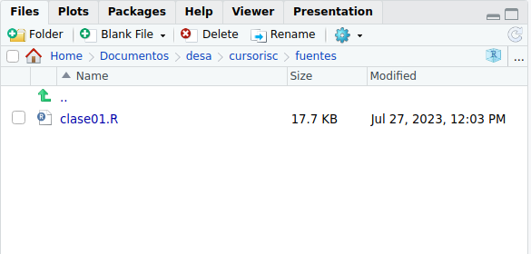

*datos*: Aca ponemos los datos que iremos descargando. Entre otros, acá descargamos y descomprimimos **eah2025_bu_ampliada.zip**

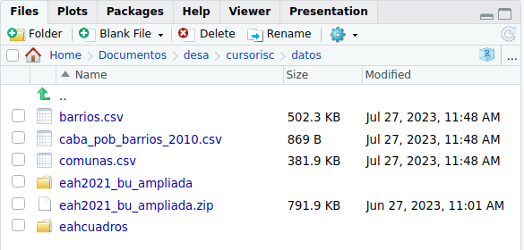

```r
# https://readr.tidyverse.org/
library(readr)

# usamos read_csv2 porque el delimitador del archivo es ";"
eah2025_ind <- read_csv2("./datos/eah2025_bu_ampliada/eah2025_bu_ampliada_ind.txt")
```

```
## ℹ Using "','" as decimal and "'.'" as grouping mark. Use `read_delim()` for more control.
```

```r
head(eah2025_ind)
```

```
## # A tibble: 6 × 237
##      id nhogar miembro comuna dominio  edad  sexo parentes_5  p5_2  p6_a  p6_b
##   <dbl>  <dbl>   <dbl>  <dbl>   <dbl> <dbl> <dbl>      <dbl> <dbl> <dbl> <dbl>
## 1     1      1       1      5       4    17     1          1     6    95    95
## 2     2      1       1      3       4    18     1          1     6     2    95
## 3     2      1       2      3       4    61     1          6     3     0     0
## 4     2      1       3      3       4    92     1          7     4     0     0
## 5     3      1       1      8       3    18     2          1     6    95     4
## 6     3      1       2      8       3    13     1          7     0    95     4
## # ℹ 226 more variables: t1 <dbl>, t2 <dbl>, t3 <dbl>, t4_1 <dbl>, t5_1 <dbl>,
## #   t5_1a <dbl>, t6_1 <dbl>, t7 <dbl>, t8 <dbl>, t9 <dbl>, t10 <dbl>,
## #   t11_0 <dbl>, t11_1 <dbl>, t12 <dbl>, estado <dbl>, t12_bis <dbl>,
## #   t11_2 <dbl>, t13_0 <dbl>, t13_0_espe <dbl>, t13 <dbl>, t14 <dbl>,
## #   t15 <dbl>, t18 <dbl>, t18_0 <dbl>, t19 <dbl>, t20_1 <dbl>, t21_1 <dbl>,
## #   t22_1 <dbl>, t48a_d <dbl>, t48b_d <dbl>, t48c_d <dbl>, t50d_a <dbl>,
## #   t50d_b <dbl>, t50d_c <dbl>, t50d_d <dbl>, t50d_e <dbl>, t50d_f <dbl>, …
```

```r
# tiene que coincidir con los 12.457 que dice eah2021_bu_ampliada_totales_de_control.xls
nrow(eah2025_ind)
```

```
## [1] 12457
```

```r
ncol(eah2025_ind)
```

```
## [1] 237
```

```r
# https://dplyr.tidyverse.org/
library(dplyr)
```

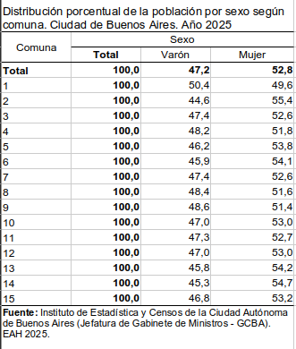

[Cuadro 01 Colab](https://colab.research.google.com/drive/12gvYPH5pTGgMmpYnDWOP6m-Q95hFHvno?usp=sharing)

```r
library(dplyr)
# tiene que coincidir con los 3.086.714 que dice eah2021_bu_ampliada_totales_de_control.xls
eah2025_ind %>% count(sexo, wt=fexp) %>% summarise(tot = sum(n))
```

```
## # A tibble: 1 × 1
##       tot
##     <dbl>
## 1 3086714
```

```r
eah2025_ind %>% count(sexo, wt=fexp) %>% mutate(porc = n / sum(n))
```

```
## # A tibble: 2 × 3
##    sexo       n  porc
##   <dbl>   <dbl> <dbl>
## 1     1 1456604 0.472
## 2     2 1630110 0.528
```

```r
eah2025_ind %>% count(comuna, sexo, wt=fexp)
```

```
## # A tibble: 30 × 3
##    comuna  sexo      n
##     <dbl> <dbl>  <dbl>
##  1      1     1 130749
##  2      1     2 128483
##  3      2     1  66575
##  4      2     2  82823
##  5      3     1  91919
##  6      3     2 101990
##  7      4     1 116192
##  8      4     2 124992
##  9      5     1  86891
## 10      5     2 101156
## # ℹ 20 more rows
```

```r
eah2025_ind$sexo <- factor(eah2025_ind$sexo, c(1,2), c('Varon','Mujer'))

eah2025_ind %>% group_by(comuna) %>%  count( sexo, wt=fexp) %>% mutate(porc = n / sum(n))
```

```
## # A tibble: 30 × 4
## # Groups:   comuna [15]
##    comuna sexo       n  porc
##     <dbl> <fct>  <dbl> <dbl>
##  1      1 Varon 130749 0.504
##  2      1 Mujer 128483 0.496
##  3      2 Varon  66575 0.446
##  4      2 Mujer  82823 0.554
##  5      3 Varon  91919 0.474
##  6      3 Mujer 101990 0.526
##  7      4 Varon 116192 0.482
##  8      4 Mujer 124992 0.518
##  9      5 Varon  86891 0.462
## 10      5 Mujer 101156 0.538
## # ℹ 20 more rows
```

```r
# https://tidyr.tidyverse.org/
# install.packages("tidyr") # also installing the dependencies ‘stringi’, ‘purrr’, ‘stringr’
library(tidyr)
eah2025_ind %>% group_by(comuna) %>%  count( sexo, wt=fexp) %>% mutate(porc = n / sum(n)) %>%
  pivot_wider(names_from = sexo, values_from = c(n, porc))
```

```
## # A tibble: 15 × 5
## # Groups:   comuna [15]
##    comuna n_Varon n_Mujer porc_Varon porc_Mujer
##     <dbl>   <dbl>   <dbl>      <dbl>      <dbl>
##  1      1  130749  128483      0.504      0.496
##  2      2   66575   82823      0.446      0.554
##  3      3   91919  101990      0.474      0.526
##  4      4  116192  124992      0.482      0.518
##  5      5   86891  101156      0.462      0.538
##  6      6   85401  100604      0.459      0.541
##  7      7  115108  127785      0.474      0.526
##  8      8  111773  119002      0.484      0.516
##  9      9   83550   88367      0.486      0.514
## 10     10   80406   90508      0.470      0.530
## 11     11   89873  100326      0.473      0.527
## 12     12  101227  114289      0.470      0.530
## 13     13  108430  128363      0.458      0.542
## 14     14  103012  124338      0.453      0.547
## 15     15   85498   97084      0.468      0.532
```

```r
library(readxl)
# install.packages("readxl")  # also installing the dependencies ‘rematch’, ‘cellranger’
p01 <- read_excel("./datos/eahcuadros/P01.xlsx", sheet = "2025")
names(p01)
```

```
## [1] "Distribución porcentual de la población por sexo según comuna. Ciudad de Buenos Aires. Año 2025"
## [2] "...2"
## [3] "...3"
## [4] "...4"
```

```r
head(p01)
```

```
## # A tibble: 6 × 4
##   Distribución porcentual de la población por sexo según com…¹ ...2  ...3  ...4
##   <chr>                                                        <chr> <chr> <chr>
## 1 Comuna                                                       Sexo  <NA>  <NA>
## 2 <NA>                                                         Total Varón Mujer
## 3 Total                                                        100   47.2  52.8
## 4 1                                                            100   50.4  49.6
## 5 2                                                            100   44.6  55.4
## 6 3                                                            100   47.4  52.6
## # ℹ abbreviated name:
## #   ¹`Distribución porcentual de la población por sexo según comuna. Ciudad de Buenos Aires. Año 2025`
```

```r
# https://cienciadedatos.github.io/r4ds/20-vectors.html

# El operador [[ ]] (corchete doble) Extrae el contenido interno del elemento. Solo funciona con un único índice.

p01[[1]][3:18]
```

```
##  [1] "Total" "1"     "2"     "3"     "4"     "5"     "6"     "7"     "8"
## [10] "9"     "10"    "11"    "12"    "13"    "14"    "15"
```

```r
comuna <- p01[[1]][3:18]
varon <- as.numeric(p01[[3]][3:18])
mujer <- as.numeric(p01[[4]][3:18])

#mp01 <- matrix(c(as.numeric(p01[[3]][3:18]), as.numeric(p01[[4]][3:18])), ncol = 2,
#       dimnames = list(p01[[1]][3:18], c("Varon","Mujer")))

mp01 <- tibble(Comuna = comuna, Varon = varon, Mujer = mujer,
               Total = varon + mujer)

str(mp01)
```

```
## tibble [16 × 4] (S3: tbl_df/tbl/data.frame)
##  $ Comuna: chr [1:16] "Total" "1" "2" "3" ...
##  $ Varon : num [1:16] 47.2 50.4 44.6 47.4 48.2 46.2 45.9 47.4 48.4 48.6 ...
##  $ Mujer : num [1:16] 52.8 49.6 55.4 52.6 51.8 53.8 54.1 52.6 51.6 51.4 ...
##  $ Total : num [1:16] 100 100 100 100 100 100 100 100 100 100 ...
```

```r
mp01
```

```
## # A tibble: 16 × 4
##    Comuna Varon Mujer Total
##    <chr>  <dbl> <dbl> <dbl>
##  1 Total   47.2  52.8   100
##  2 1       50.4  49.6   100
##  3 2       44.6  55.4   100
##  4 3       47.4  52.6   100
##  5 4       48.2  51.8   100
##  6 5       46.2  53.8   100
##  7 6       45.9  54.1   100
##  8 7       47.4  52.6   100
##  9 8       48.4  51.6   100
## 10 9       48.6  51.4   100
## 11 10      47    53     100
## 12 11      47.3  52.7   100
## 13 12      47    53     100
## 14 13      45.8  54.2   100
## 15 14      45.3  54.7   100
## 16 15      46.8  53.2   100
```

##### Para crear gráficos con *ggplot* hay que instalar el paquete con *install.package()*, por única vez.

##### Luego hay que cargarlo con *library()* la primera vez que lo queremos usar en una sesión.

```r
# install.packages("ggplot2")
library(ggplot2)
```

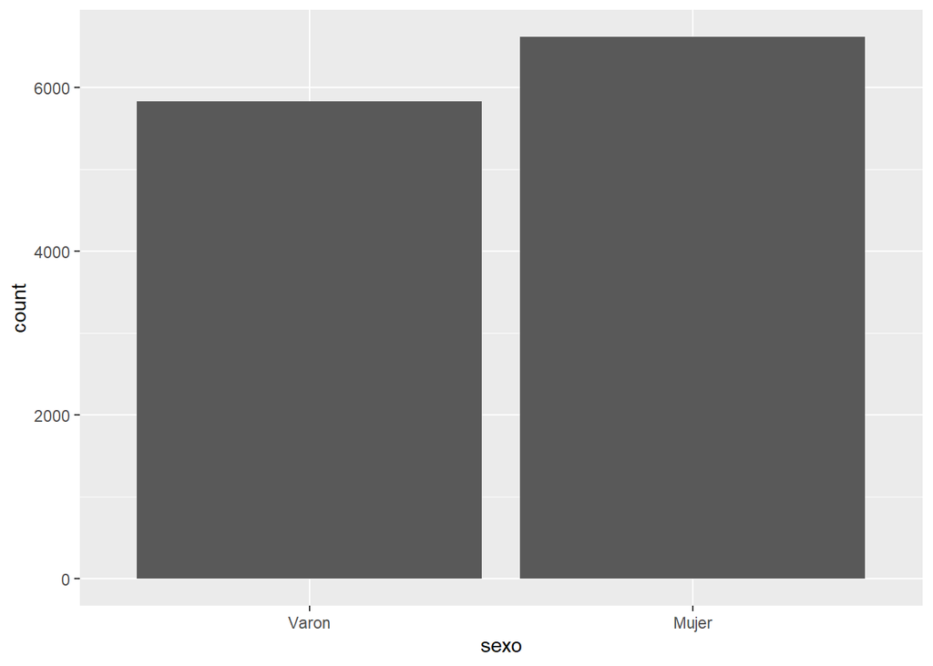

```r
ggplot(eah2025_ind, aes(sexo)) +
  geom_bar()
```

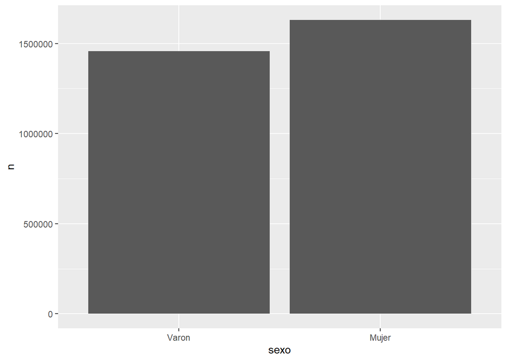

```r
ggplot(eah2025_ind %>% count(sexo, wt = fexp), aes(sexo, n)) +
  geom_bar(stat="identity")
```

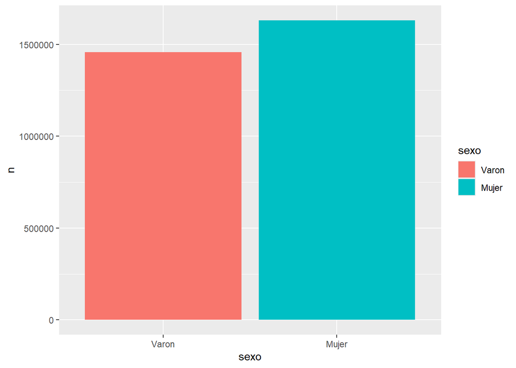

```r
ggplot(eah2025_ind %>% count(sexo, wt = fexp), aes(sexo, n, fill=sexo)) +
  geom_bar(stat="identity")
```

```r
xcomuna_totsexo <- eah2025_ind %>% group_by(comuna) %>%  count( sexo, wt=fexp)

xcomuna_totsexo
```

```
## # A tibble: 30 × 3
## # Groups:   comuna [15]
##    comuna sexo       n
##     <dbl> <fct>  <dbl>
##  1      1 Varon 130749
##  2      1 Mujer 128483
##  3      2 Varon  66575
##  4      2 Mujer  82823
##  5      3 Varon  91919
##  6      3 Mujer 101990
##  7      4 Varon 116192
##  8      4 Mujer 124992
##  9      5 Varon  86891
## 10      5 Mujer 101156
## # ℹ 20 more rows
```

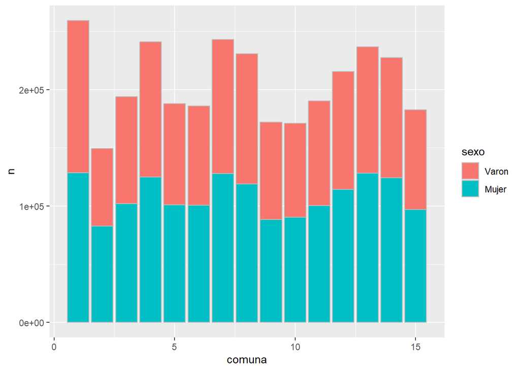

```r
ggplot(xcomuna_totsexo, aes(comuna, n, fill=sexo)) +
  geom_bar(stat="identity", colour = "grey")
```

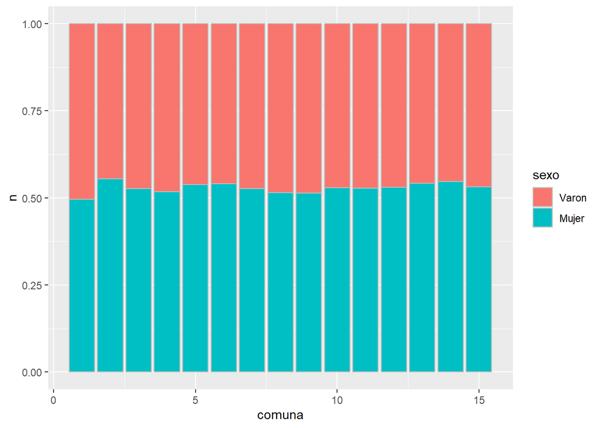

```r
ggplot(xcomuna_totsexo, aes(comuna, n, fill=sexo)) +
  geom_bar(stat="identity", position = "fill", colour = "grey")
```

### Bibliografia:

#### [Cheat Sheet *dplyr*](https://dplyr.tidyverse.org/index.html#cheat-sheet)

#### [Ciencia de Datos y Políticas Públicas](https://datosgcba.github.io/ciencia-de-datos-politicas-publicas/docs/)

#### [Ciencia de Datos para Gente Sociable](https://bitsandbricks.github.io/ciencia_de_datos_gente_sociable/)

#### [Introducción a R para Ciencias Sociales. Aplicación practica en la EPH](https://diegokoz.github.io/R_EPH_bookdown/index.html)

#### [R Para Ciencia de Datos](https://cienciadedatos.github.io/r4ds/)

clase01.R

[figure not shown]